# Applying Machine Learning Models for Predicting Human Activity Performance

Sheila Zhao

17 June 2015

## Background

Many people now regularly use personal activity tracking devices such as Jawbone Up, Nike FuelBand, and Fitbit to quantify how much of a particular activity they do, but these devices rarely quantify how well they do those activities.

The goal of this project is to show how machine learning models may be applied for predicting the manner that a particular tracked activity was performed based on the motion measurement data that was collected from the sensors attached to the person performing the activity.

## Dataset

The dataset used for this project is the Weight Lifting Exercise Dataset, taken from a study in Qualitative Activity Recognition by Velloso, et al. More information on this study and the dataset are available from the website : http://groupware.les.inf.puc-rio.br/har and the paper cited in the References section.

The dataset contains sensor measurements taken from six young healthy participants as they performed the Unilateral Dumbbell Biceps Curl in five different ways, and records the manner they had performed the activity in a *classe* variable as follows:

- Class A : performed exactly according to the specification
- Class B : throwing the elbows to the front
- Class C : lifting the dumbbell only halfway
- Class D : lowering the dumbbell only halfway
- Class E : throwing the hips to the front

By training machine learning models for classification on this dataset, the fitted models could learn to predict the value of *classe* from the sensor measurements recorded for new observations data.

```
## [1] "LC_COLLATE=English_United States.1252;LC_CTYPE=English_United States.1252;LC_MONETARY=English_United States.1252;LC_NUMERIC=C;LC_TIME=English_United States.1252"
```

## Exploratory Data Analysis

```r
# Load the raw training dataset from current working directory
train_raw <- read.csv("pml-training.csv", na.strings=c("NA","#DIV/0!",""))

# Check how many rows and columns per row in the dataset
dim(train_raw)
```

```
## [1] 19622   160
```

After loading the training dataset, a quick check of the dataset showed that it comprised of 19622 records and each record has 160 columns.

We performed an exploratory scan of the dataset and we observed that there are two types of records in the dataset:

- observation records (new_window=“no”), which records the measurements from the sensors for the activity performed.
- summary records (new_window=yes), which aggregates the measurements into the summary statistics columns for a given time window.

Here is some exploratory data analysis performed.

```r
head(train_raw[20:30,c(1:2, 5:10, 18:22,160)], 8)
```

```
##     X user_name   cvtd_timestamp new_window num_window roll_belt
## 20 20  carlitos 05/12/2011 11:23         no         12      1.59
## 21 21  carlitos 05/12/2011 11:23         no         12      1.60
## 22 22  carlitos 05/12/2011 11:23         no         12      1.57
## 23 23  carlitos 05/12/2011 11:23         no         12      1.56
## 24 24  carlitos 05/12/2011 11:23        yes         12      1.51
## 25 25  carlitos 05/12/2011 11:23         no         13      1.53
## 26 26  carlitos 05/12/2011 11:23         no         13      1.55
## 27 27  carlitos 05/12/2011 11:23         no         13      1.54
##    pitch_belt yaw_belt max_roll_belt max_picth_belt max_yaw_belt
## 20       8.07    -94.4            NA             NA           NA
## 21       8.10    -94.4            NA             NA           NA
## 22       8.09    -94.4            NA             NA           NA
## 23       8.10    -94.3            NA             NA           NA
## 24       8.10    -94.4         -94.3              3          5.6
## 25       8.11    -94.4            NA             NA           NA
## 26       8.09    -94.4            NA             NA           NA
## 27       8.11    -94.4            NA             NA           NA
##    min_roll_belt min_pitch_belt classe
## 20            NA             NA      A
## 21            NA             NA      A
## 22            NA             NA      A
## 23            NA             NA      A
## 24         -94.4              3      A
## 25            NA             NA      A
## 26            NA             NA      A
## 27            NA             NA      A
```

```r
summary(train_raw$roll_belt)
```

```
##    Min. 1st Qu.  Median    Mean 3rd Qu.    Max.
##  -28.90    1.10  113.00   64.41  123.00  162.00
```

```r
summary(train_raw$min_roll_belt)
```

```
##    Min. 1st Qu.  Median    Mean 3rd Qu.    Max.    NA's
## -180.00  -88.40   -7.85  -10.44    9.05  173.00   19216
```

```r
summary(train_raw$classe)
```

```
##    A    B    C    D    E
## 5580 3797 3422 3216 3607
```

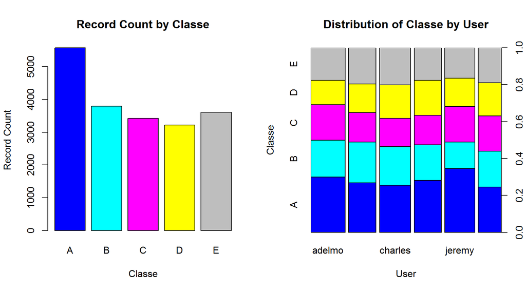

## Data Cleansing and Preparation

For the purpose of predicting the value of classe from the observed sensor data, only observation records are required. Summary records are not required and has to be removed from the training dataset.

Summary statistic columns of observation records have NA values, and shall be removed as they are redundant for our prediction models.

Finally, the first seven columns are dimensional data, which do not contribute to our prediction model. They shall also be removed from the training dataset.

```r
# remove all summary records indicated by new_window=yes
train_clean <- train_raw[train_raw$new_window == "no", ]

# remove summary stats columns which have NA values in remaining observation records
train_clean <- train_clean[,colSums(is.na(train_clean)) != nrow(train_clean)]

# remove dimension columns not used in prediction model
train_clean <- train_clean[,-c(1:7)]
dim(train_clean)
```

```
## [1] 19216    53
```

## Partitioning Training Data for Cross-Validation

In order to cross-validate the predictive accuracy of the classificatin models we will create and test, we need to first partition the cleansed training dataset.

We will use 70% of the cleansed training dataset for model training, and set aside 30% of the cleansed dataset as the validation dataset, which we will use measuring the out-of-sample errors and comparing the prediction accuracy of our prediction models we are building.

```r
# split train_clean to train_ds and val_ds for cross validation
in_train <- createDataPartition(y=train_clean$classe, p=0.70, list=FALSE)
train_ds <- train_clean[in_train,]       # 70% training   13453    53
val_ds <- train_clean[-in_train,]        # 30% validation 5763   53
```

## Model 1: Decision Tree Model

We first fitted a Decision Tree model to the training dataset , which is commonly used for classification problems and one of the easiest predictive models to understand .

### Model Training

The tree model is fitted to the training dataset as follows, and the resulting tree model fit is illustrated by the figure below.

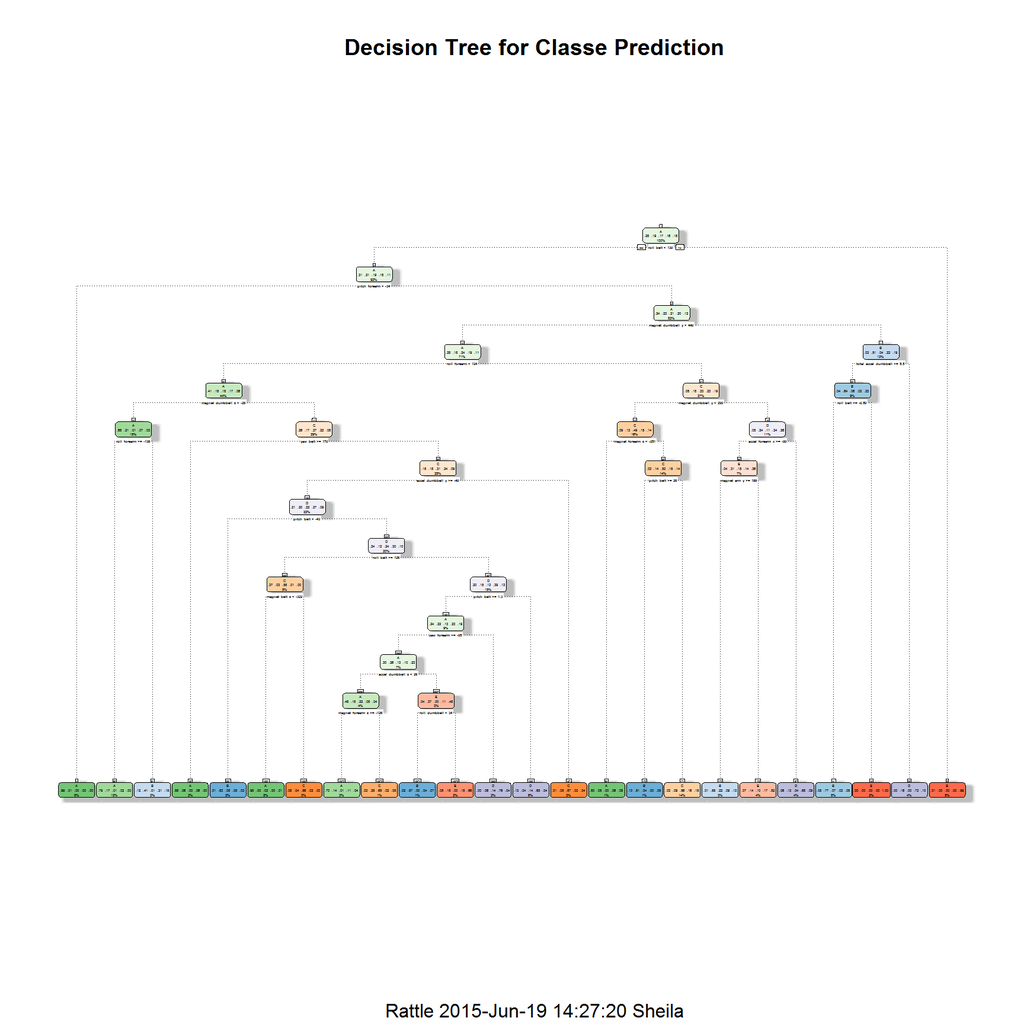

```r
set.seed(12345)
# fit the tree model to the training dataset
rpart_fit <- rpart(classe ~ ., data=train_ds, method="class")

# print the fitted tree
fancyRpartPlot(rpart_fit, main="Decision Tree for Classe Prediction")
```

### Model Validation

```r
rpart_predicted <- predict(rpart_fit, newdata=val_ds, type="class")
rpart_cm <- confusionMatrix(val_ds$classe, rpart_predicted)
rpart_cm
```

```
## Confusion Matrix and Statistics
##
##           Reference
## Prediction    A    B    C    D    E
##          A 1433   54   42   76   36
##          B  164  692  113   84   62
##          C   15   81  812   69   28
##          D   53   76  143  604   68
##          E   19   92  130   56  761
##
## Overall Statistics
##
##                Accuracy : 0.7465
##                  95% CI : (0.735, 0.7577)
##     No Information Rate : 0.2922
##     P-Value [Acc > NIR] : < 2.2e-16
##
##                   Kappa : 0.6792
##  Mcnemar's Test P-Value : < 2.2e-16
##
## Statistics by Class:
##
##                      Class: A Class: B Class: C Class: D Class: E
## Sensitivity            0.8510   0.6955   0.6548   0.6794   0.7969
## Specificity            0.9490   0.9113   0.9573   0.9302   0.9382
## Pos Pred Value         0.8732   0.6206   0.8080   0.6398   0.7193
## Neg Pred Value         0.9391   0.9348   0.9100   0.9409   0.9588
## Prevalence             0.2922   0.1727   0.2152   0.1543   0.1657
## Detection Rate         0.2487   0.1201   0.1409   0.1048   0.1320
## Detection Prevalence   0.2847   0.1935   0.1744   0.1638   0.1836
## Balanced Accuracy      0.9000   0.8034   0.8061   0.8048   0.8675
```

## Model 2 - Random Forest Model Using All Predictors

As another commonly used prediction model for classification problems, Random Forest model is known for its accuracy of prediction, but is both compute-expensive and more difficult to interpret.

For our second prediction model, we chose a Random Forest model using all 52 predictor variables in the dataset and using 7 folds for cross validation.

### Model Training

```r
set.seed(12345)
no_of_folds <- 7

# Setting up the seeds argument for TrainControl to ensure reproducibility
seeds <- vector(mode = "list", length = no_of_folds)
for(i in 1:no_of_folds) seeds[[i]] <- sample.int(1000, 3)
seeds[[no_of_folds + 1]] <- sample.int(1000, 1)

trc <- trainControl(method="cv", number=no_of_folds, seeds=seeds)

rf_fit <- train(classe ~ ., method="rf", data=train_ds, ntrees=250, prox=FALSE,
                trControl=trc)
print(rf_fit$finalModel)
```

```
##
## Call:
##  randomForest(x = x, y = y, mtry = param$mtry, proximity = FALSE,      ntrees = 250)
##                Type of random forest: classification
##                      Number of trees: 500
## No. of variables tried at each split: 2
##
##         OOB estimate of  error rate: 0.69%
## Confusion matrix:
##      A    B    C    D    E  class.error
## A 3830    0    0    0    0 0.0000000000
## B   12 2580   11    0    0 0.0088359585
## C    0   18 2325    4    0 0.0093736685
## D    0    0   44 2157    2 0.0208806173
## E    0    0    1    1 2468 0.0008097166
```

### Model Validation

```r
rf_predicted <- predict(rf_fit, newdata=val_ds)
rf_cm <- confusionMatrix(val_ds$classe, rf_predicted)
rf_cm
```

```
## Confusion Matrix and Statistics
##
##           Reference
## Prediction    A    B    C    D    E
##          A 1640    1    0    0    0
##          B   11 1100    4    0    0
##          C    0    6  999    0    0
##          D    0    0   16  927    1
##          E    0    0    0    3 1055
##
## Overall Statistics
##
##                Accuracy : 0.9927
##                  95% CI : (0.9902, 0.9947)
##     No Information Rate : 0.2865
##     P-Value [Acc > NIR] : < 2.2e-16
##
##                   Kappa : 0.9908
##  Mcnemar's Test P-Value : NA
##
## Statistics by Class:
##
##                      Class: A Class: B Class: C Class: D Class: E
## Sensitivity            0.9933   0.9937   0.9804   0.9968   0.9991
## Specificity            0.9998   0.9968   0.9987   0.9965   0.9994
## Pos Pred Value         0.9994   0.9865   0.9940   0.9820   0.9972
## Neg Pred Value         0.9973   0.9985   0.9958   0.9994   0.9998
## Prevalence             0.2865   0.1921   0.1768   0.1614   0.1832
## Detection Rate         0.2846   0.1909   0.1733   0.1609   0.1831
## Detection Prevalence   0.2847   0.1935   0.1744   0.1638   0.1836
## Balanced Accuracy      0.9965   0.9952   0.9896   0.9966   0.9992
```

## Model 3 - Random Forest Model Using Key Predictors

For our third and final prediction model, we built a second Random Forest model using a smaller subset of the predictors, but achieving a comparable level of accuracy as the model using all 52 variables.

### Feature Selection

To select the predictors for the third model, we start by examining the variable importance of our earlier Random Forest Model. We found that 13 of the 52 predictor variables are the most important contributing variables to the prediction model.

This is illustrated in the following variable importance plot.

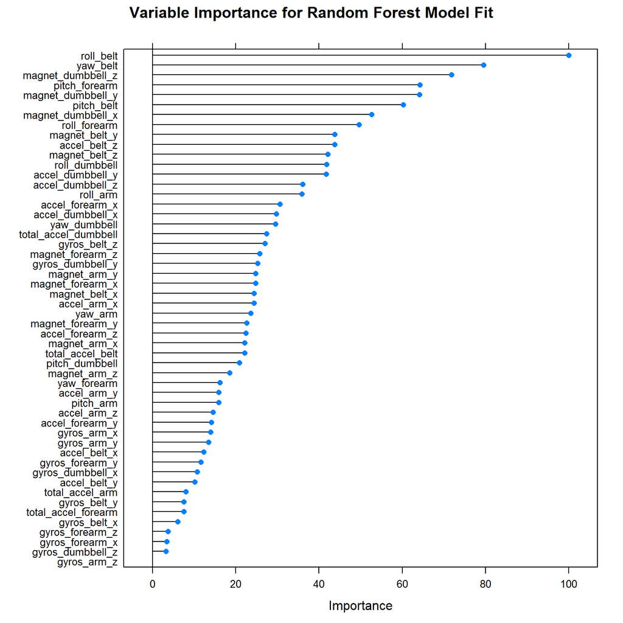

```r
rf_vi <- varImp(rf_fit)
plot(rf_vi, main="Variable Importance for Random Forest Model Fit")
```

```r
imp <- rf_vi$importance
imp_vars <- rownames(imp)[imp$Overall > 40]
imp_vars
```

```
##  [1] "roll_belt"         "pitch_belt"        "yaw_belt"
##  [4] "accel_belt_z"      "magnet_belt_y"     "magnet_belt_z"
##  [7] "roll_dumbbell"     "accel_dumbbell_y"  "magnet_dumbbell_x"
## [10] "magnet_dumbbell_y" "magnet_dumbbell_z" "roll_forearm"
## [13] "pitch_forearm"
```

### Model Training

```r
set.seed(12345)
train_ds2 <- train_ds[,c("classe",imp_vars)]
rf_fit2 <- train(classe ~ ., method="rf", data=train_ds2, ntrees=250, prox=FALSE,
                trControl=trc)
print(rf_fit2$finalModel)
```

```
##
## Call:
##  randomForest(x = x, y = y, mtry = param$mtry, proximity = FALSE,      ntrees = 250)
##                Type of random forest: classification
##                      Number of trees: 500
## No. of variables tried at each split: 7
##
##         OOB estimate of  error rate: 1.64%
## Confusion matrix:
##      A    B    C    D    E class.error
## A 3798   16   14    2    0 0.008355091
## B   31 2514   40   17    1 0.034191318
## C    3   23 2300   21    0 0.020025565
## D    0    4   25 2172    2 0.014071720
## E    0    6    7    8 2449 0.008502024
```

### Model Validation

```r
rf_predicted2 <- predict(rf_fit2, newdata=val_ds)
rf_cm2 <- confusionMatrix(val_ds$classe, rf_predicted2)
rf_cm2
```

```
## Confusion Matrix and Statistics
##
##           Reference
## Prediction    A    B    C    D    E
##          A 1633    2    4    2    0
##          B    9 1084   15    7    0
##          C    0    7  991    7    0
##          D    0    0   13  928    3
##          E    0    5    1    2 1050
##
## Overall Statistics
##
##                Accuracy : 0.9866
##                  95% CI : (0.9833, 0.9894)
##     No Information Rate : 0.2849
##     P-Value [Acc > NIR] : < 2.2e-16
##
##                   Kappa : 0.9831
##  Mcnemar's Test P-Value : NA
##
## Statistics by Class:
##
##                      Class: A Class: B Class: C Class: D Class: E
## Sensitivity            0.9945   0.9872   0.9678   0.9810   0.9972
## Specificity            0.9981   0.9934   0.9970   0.9967   0.9983
## Pos Pred Value         0.9951   0.9722   0.9861   0.9831   0.9924
## Neg Pred Value         0.9978   0.9970   0.9931   0.9963   0.9994
## Prevalence             0.2849   0.1905   0.1777   0.1642   0.1827
## Detection Rate         0.2834   0.1881   0.1720   0.1610   0.1822
## Detection Prevalence   0.2847   0.1935   0.1744   0.1638   0.1836
## Balanced Accuracy      0.9963   0.9903   0.9824   0.9888   0.9977
```

## Prediction on the Testing Dataset

In this final section, we loaded the testing dataset and confirmed that the testing dataset contained 20 test cases, but the response variable *classe* was missing, and replaced by another variable called **problem_id**. As a result, we had to insert the *classe* column back into the dataset in line with our fitted Random Forest model.

```r
test_raw <- read.csv("pml-testing.csv", na.strings=c("NA","#DIV/0!",""))
dim(test_raw)
```

```
## [1]  20 160
```

```r
test_ds <- test_raw
test_ds$classe <- NA
```

```r
set.seed(12345)
problem_id <- test_ds$problem_id
test_ds <- test_ds[,colnames(train_ds2)]
predicted_classe <- predict(rf_fit2, newdata=test_ds)
data.frame(problem_id, predicted_classe)
```

```
##    problem_id predicted_classe
## 1           1                B
## 2           2                A
## 3           3                B
## 4           4                A
## 5           5                A
## 6           6                E
## 7           7                D
## 8           8                B
## 9           9                A
## 10         10                A
## 11         11                B
## 12         12                C
## 13         13                B
## 14         14                A
## 15         15                E
## 16         16                E
## 17         17                A
## 18         18                B
## 19         19                B
## 20         20                B
```

The predicted answers for all 20 test cases were submitted to Coursera web site for checking, which confirmed the values of *classe* for all 20 test cases were predicted correctly.

## Conclusions

This project has shown how Decision Tree and Random Forest predictive models can be applied for predicting the manner that a particular tracked activity was performed from the motion measurement data that was collected from the sensors attached to persons performing the activity.

Random Forest models achieved better predictive accuracy as compared to Decision Tree models, but require much more computing resources to execute.

The validation results for the three prediction models are illustrated in the following plot, which compares the prediction accuracy achieved by each prediction model fitted against the validation dataset.

[figure not shown]

From the plot, it is clear that the Random Forest Models predicts much more accurately than the Decision Tree Model, but there is little difference in overall accuracy achieved between the two Random Forest Models themselves.

## References

1. Velloso, E.; Bulling, A.; Gellersen, H.; Ugulino, W.; Fuks, H. Qualitative Activity Recognition of Weight Lifting Exercises. Proceedings of 4th International Conference in Cooperation with SIGCHI (Augmented Human ’13) . Stuttgart, Germany: ACM SIGCHI, 2013.